# Ali Wilkening, Nucleosome Pulldown Report

Mike Trnka

Sep 26 2023

### Experiment description

Ali prepared samples. She has nucleosomes prepared with variant H2A.Z histones in place of canonical H2A. Mononucleosomes are prepared on biotinylated 601 DNA positioning sequence. hESC nuclear lysates (500 µg) were IPed over streptavidin imobilized mononucleosomes (2 µg). Samples were sent to UCSF and on bead trypsin digests using standard UCSF protocol performed by Kathy Li (Sept 1, 2023-ish).

5 Samples included:

Peptides were taken up in 7$\mu l$ of 0.1% formic acid and 5$\mu l$ injected for MS analysis.

- **Equipment:**
  - EasySpray C<sub>18</sub> 75$\mu m$ x 50mm column (Thermo)
  - Dionex Ultimate 3000 UPLC system (Thermo).
  - Orbitrap Exploris MS (Thermo)
  - EasySpray nanoESI source (Thermo).
- **Acquisition Method:**
  - Precursors acquired at 120k in Orbitrap.
  - HCD fragmentation at 30NCE.
  - Product ions measured at 60k in Orbitrap.
  - 4h LCMS runs.
- **File List:**
  - Z20230911-02: **H2A.Z1**
  - Z20230911-03: **H2A.Z2**
  - Z20230911-04: **H2A.Z1.S38T**
  - Z20230911-05: **biotinylatedDNA**
  - Z20230911-06: **beads only**
- **Data Processing:**
  - Peaklists generated with PAVA-MP
  - Searched with Prospector v6.4.8 (installed on pplab server)
  - DB: UniProtKB.2022.10.25.random.concat **HUMAN**. Trypsin. 2 missed cleavages. Some additional contaminant sequences added. (205,893 Target + 205,893 Decoy sequences).
  - precursor/product tolerance = 10/30 ppm.
  - standard mods plus Deamindation on N/Q.
  - results reported at 1%/1% Protein/Peptide FDR. Multisample with Spectral Counts.
  - reported INTERESTING homologs.
  - Additional analysis in R:

### Analysis

```r
setwd("~/Projects-Collaboration/SanulliLab/Ali/")
pid <- read_tsv("S230911_humanish_NONE_consistACC.txt", skip=2)
pid <- pid %>%
   #filter(`Num Unique` > 1, `Uniq Pep` > 3 | is.na(`Uniq Pep`), `Acc #` != "decoy") %>%
   filter(`Num Unique` > 1, `Acc #` != "decoy") %>%
   mutate(SAF = 100 * `Peptide Count` / `Protein Length`,
          Sample = case_when(ID == 1 ~ "H2A.Z1",
                             ID == 2 ~ "H2A.Z2",
                             ID == 3 ~ "H2A.Z1.S38T",
                             ID == 4 ~ "biotinylatedDNA",
                             ID == 5 ~ "beads only")
   )
```

Protein’s were classified 1% FDR. Additionally, I required at least 2 unique peptides for a protein ID or 4 to report a homologous protein. There were a lot of issues showing up that were caused by inconsistent homolog reporting (eg, homolog was filtered out of the control experiment but not the target. After first pass analysis, many seemingly positively enriched proteins were actually just caused due to sloppy assigning of peptides to different isoforms. In the future this could be handled more elegantly. For the time being, I decided to only report a single isoform/homology for each set of matching peptides.

Numbers of proteins / peptides etc, identified are given below. I was expecting to ID ~1500-2000 proteins per sample based on previous experiments with Hayden.

For comparison, I’m including results from a paper from Vermulen lab. I downloaded the raw files and processed their data through our pipeline. They started with with 35 µg of di-nucleosomes pulling down 500 µg of nuclear lysate from HeLa cells and report about 2000 proteins in their TMT labeled samples (eg, I think each pulldown used 5 µg and they combined 7 channels).

https://www.nature.com/articles/s41467-018-04084-0

Generally, the overall numbers of proteins / peptide / spectral matches seem within reason for the sample and instrument conditions, if a little on the low side. Number are probably lower because of the way I am disregarding homologs right now.

| Table 1. Search Result Statistics per Sample 1% Protein FDR. 1% Peptide FDR Sample | Table 1. Search Result Statistics per Sample 1% Protein FDR. 1% Peptide FDR num.proteins | Table 1. Search Result Statistics per Sample 1% Protein FDR. 1% Peptide FDR num.proteins.distinct | Table 1. Search Result Statistics per Sample 1% Protein FDR. 1% Peptide FDR num.peptides | Table 1. Search Result Statistics per Sample 1% Protein FDR. 1% Peptide FDR num.spectral.matches |
| --- | --- | --- | --- | --- |
| beads only | 1,145 | 1,145 | 10,646 | 17,059 |
| biotinylatedDNA | 1,560 | 1,560 | 15,395 | 23,788 |
| H2A.Z1 | 1,026 | 1,026 | 9,049 | 14,660 |
| H2A.Z1.S38T | 1,355 | 1,355 | 12,792 | 20,201 |
| H2A.Z2 | 1,133 | 1,133 | 9,990 | 15,927 |
| Makowski et 2018 | 2,100 | 1,888 | 14,555 | 15,208 |

##### Transorming the data into a matrix across all 5 runs and normalizing spectral counts across runs:

```r
pid2 <- pid %>%
   group_by(`Acc #`, `Gene`, Sample) %>%
   summarize(counts = sum(`Peptide Count`, na.rm=T)) %>%
   pivot_wider(names_from = Sample, values_from = counts) %>%
   select(Gene, starts_with("H2A"), biotinylatedDNA, `beads only`) %>%
   ungroup()

# Normalize:
pid2.norm <- pid2 %>%
   mutate(across(-c(`Acc #`, Gene), function(col) {10000*col / sum(col, na.rm=T)}))

# Show first 15 lines of table to make sure it looks right:
pid2.norm %>%
   slice(1:15) %>%
   regulartable() %>%
   autofit() %>%
   add_header_lines("Normalized Spectral Count Table")
```

| Normalized Spectral Count Table Acc # | Normalized Spectral Count Table Gene | Normalized Spectral Count Table H2A.Z1 | Normalized Spectral Count Table H2A.Z1.S38T | Normalized Spectral Count Table H2A.Z2 | Normalized Spectral Count Table biotinylatedDNA | Normalized Spectral Count Table beads only |
| --- | --- | --- | --- | --- | --- | --- |
| A0A024QYY9 | SPECC1 | 12.960437 | 11.385575 | 11.929428 | 9.668741 | 14.068820 |
| A0A024QZM0 | ASCC1 | 1.364256 | 0.990050 |  | 2.942660 |  |
| A0A024QZP1 | HNRPH3 |  | 1.485075 |  | 0.840760 | 1.172402 |
| A0A024R161 | DNAJC25-GNG10 |  | 1.485075 | 1.255729 |  |  |
| A0A024R1X6 | KRT14 | 8.185539 | 8.910450 | 10.673699 | 7.146460 | 18.172226 |
| A0A024R487 | ACSL3 | 5.457026 | 3.465175 | 5.650782 | 5.044560 | 5.275807 |
| A0A024R5M9 | NUMA1 | 12.960437 | 16.335825 | 13.813022 | 20.178241 | 9.379213 |
| A0A024R7T4 | ZNF22 |  |  |  |  | 1.758602 |
| A0A024R7T5 | ZNF485 |  |  | 1.883594 |  |  |
| A0A024RAV5 | KRAS | 2.728513 | 3.465175 | 2.511459 | 2.101900 | 3.517205 |
| A0A075B724 | TUBB8 |  |  |  | 1.261140 | 1.172402 |
| A0A087WTJ7 | TPM1 | 2.728513 | 0.990050 | 1.255729 | 1.681520 | 1.758602 |
| A0A087WWB9 | RAB13 |  | 2.970150 |  | 1.261140 | 2.931004 |
| A0A0A0MR36 | MYO5B | 9.549795 | 9.900500 | 10.045834 |  | 11.137816 |
| A0A0B4J211 | ATAD2 |  | 1.485075 | 1.255729 | 2.101900 |  |

```r
# Check that column sums are correctly normalized to 10,000:
apply(pid2.norm[3:7], 2, sum, na.rm=T)
```

```
##          H2A.Z1     H2A.Z1.S38T          H2A.Z2 biotinylatedDNA      beads only
##           10000           10000           10000           10000           10000
```

Typically, we would have 2-3 biological replicates for each bait and control experiment that we wanted to test. This would allow us to calculate means and p-values and do a volcano plot style analysis to see which proteins are enriched above background.

Since we only have a single replicate, I am going to just look at the ratio of normalized spectral counts in the bait vs the higher value between the two control conditions. Missing values were imputed as 0.1 normalized counts.

At the end, I’ve also performed the volcano plot analysis by treating the three H2A.Z pulldowns as if they were independent replicates of the same bait since that should identify interactors that are common to nucleosomes in general.

```r
pid3 <- pid2.norm %>%
   mutate(across(3:7, ~ if_else(is.na(.x), 0.1, .x))) %>%
   mutate(calculations = pmap(list(H2A.Z1,H2A.Z2,H2A.Z1.S38T,biotinylatedDNA,`beads only`),
                              function(x1,x2,x3,y1,y2) {
                                 tar = c(x1,x2,x3)
                                 con = c(y1,y2)
                                 tar.mean = mean(tar, na.rm = T)
                                 con.max = max(con, na.rm = T)
                                 tt = t.test(tar, con, na.action = na.omit)
                                 ratio_z1_con = x1 / con.max
                                 ratio_z2_con = x2 / con.max
                                 ratio_s38t_con = x3 / con.max
                                 tibble(tar.mean = tar.mean,
                                        con.max = con.max,
                                        ratio_z1_con = ratio_z1_con,
                                        ratio_z2_con = ratio_z2_con,
                                        ratio_s38t_con = ratio_s38t_con,
                                        l2.tarcon = log(tar.mean, 2) - log(con.max, 2),
                                        p.value.tarcon = tt$p.value
                                 )
                              }
   )
   ) %>%
   unnest_wider(col=calculations) %>%
   # This part filters off duplicate Gene entries and keeps only the one
   # with max counts.  This is to simplify results form all the homologous
   # proteins that map to same gene name.
   group_by(Gene) %>%
   filter(tar.mean==max(tar.mean)) %>%
   slice(1) %>%
   ungroup()
```

### Results

#### Table 2 - proteomics results, normalized and transformed.

*Table show normalized spectral counts per protein per experiment as well as means for each condition, as well as enrichment ratios*

| Acc # | Gene | H2A.Z1 | H2A.Z1.S38T | H2A.Z2 | biotinylatedDNA | beads only | tar.mean | con.max | ratio_z1_con | ratio_z2_con | ratio_s38t_con | l2.tarcon | p.value.tarcon |
| --- | --- | --- | --- | --- | --- | --- | --- | --- | --- | --- | --- | --- | --- |
| P49588 | AARS1 | 1.364 | 0.99 | 1.256 | 1.682 | 0.1 | 1.203 | 1.682 | 0.811 | 0.747 | 0.589 | -0.483 | 0.761 |
| Q9UDR5 | AASS | 8.868 | 9.9 | 10.674 | 7.987 | 12.896 | 9.814 | 12.896 | 0.688 | 0.828 | 0.768 | -0.394 | 0.841 |
| Q9NY61 | AATF | 3.411 | 4.455 | 4.395 | 4.204 | 1.759 | 4.087 | 4.204 | 0.811 | 1.045 | 1.06 | -0.041 | 0.527 |
| P28288 | ABCD3 | 0.1 | 0.99 | 0.1 | 1.261 | 0.1 | 0.397 | 1.261 | 0.079 | 0.079 | 0.785 | -1.669 | 0.717 |
| P61221 | ABCE1 | 4.093 | 5.94 | 5.651 | 5.885 | 7.621 | 5.228 | 7.621 | 0.537 | 0.742 | 0.78 | -0.544 | 0.287 |
| Q2L6I2 | ABCF1 | 3.411 | 3.465 | 3.767 | 3.363 | 3.517 | 3.548 | 3.517 | 0.97 | 1.071 | 0.985 | 0.012 | 0.484 |
| Q9UG63 | ABCF2 | 3.411 | 5.445 | 5.023 | 5.045 | 5.276 | 4.626 | 5.276 | 0.646 | 0.952 | 1.032 | -0.19 | 0.481 |
| O14639 | ABLIM1 | 6.139 | 5.445 | 6.279 | 5.885 | 6.448 | 5.954 | 6.448 | 0.952 | 0.974 | 0.844 | -0.115 | 0.624 |
| Q13085 | ACACA | 12.278 | 13.366 | 16.324 | 10.93 | 23.448 | 13.989 | 23.448 | 0.524 | 0.696 | 0.57 | -0.745 | 0.699 |
| P11310 | ACADM | 4.775 | 2.475 | 4.395 | 2.943 | 1.172 | 3.882 | 2.943 | 1.623 | 1.494 | 0.841 | 0.4 | 0.236 |

[output cut: 1611 more lines]

The data table above is sortable and can be downloaded to an excel file. The scrolling was a bit buggy in my web browser and I didn’t have time to try to troubleshoot it.

Okay, let’s see if any protein’s are enriched in the H2A.Z1 pulldown. Proteins with normalized spectral count greater than 1.5 fold over the control are labeled.

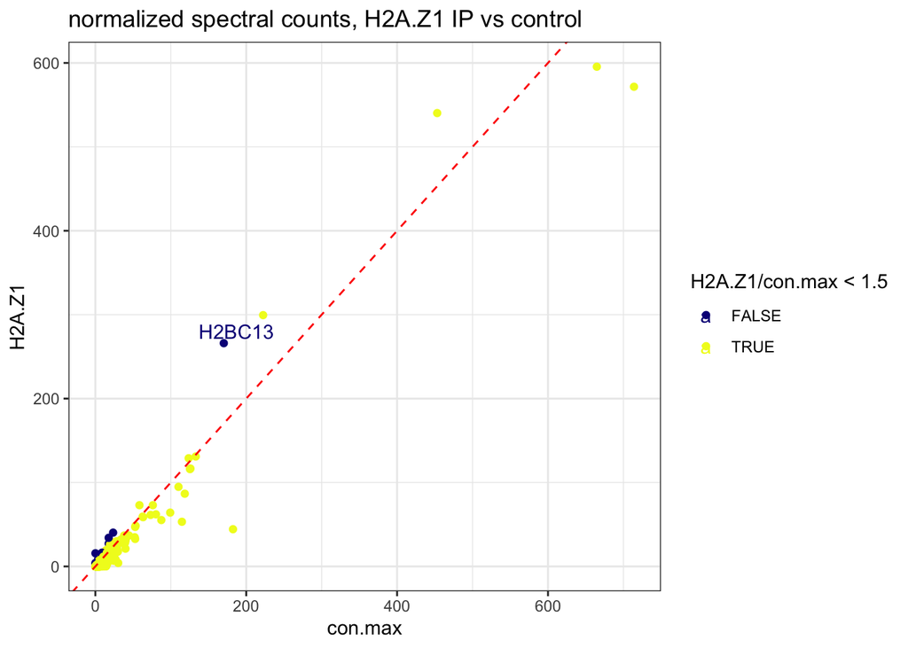

Not many proteins stand out as being significantly enriched at this level of zoom. H2B is the only one which is expected since nucleosomes are used in the AP bait.

The next plot is just a zoomed in version of the previous plot to hopefully find some specific interactors at lowerer abundances:

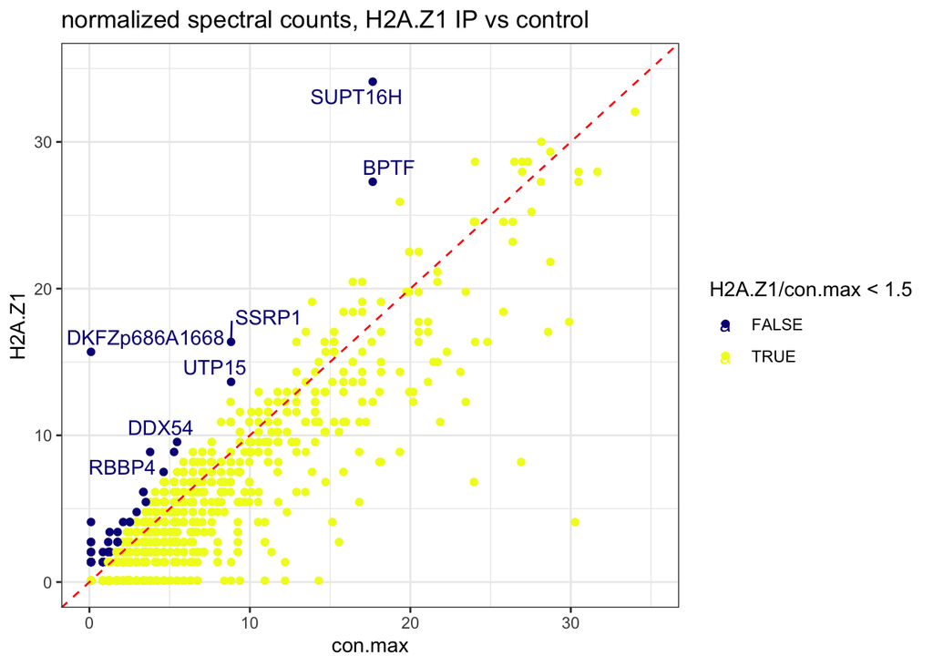

Listing the proteins that are most enriched:

| Acc # | Gene | H2A.Z1 | con.max | ratio_z1_con |
| --- | --- | --- | --- | --- |
| Q68CT4 | DKFZp686A1668 | 15.689 | 0.1 | 156.889 |
| K7EPB9 | TPM4 | 4.093 | 0.1 | 40.928 |
| Q53T70 | RAB10 | 2.729 | 0.1 | 27.285 |
| O15047 | SETD1A | 2.729 | 0.1 | 27.285 |
| Q99525 | H4C7 | 2.046 | 0.1 | 20.464 |
| Q96QR8 | PURB | 2.046 | 0.1 | 20.464 |
| Q2TBD5 | STAU2 | 2.046 | 0.1 | 20.464 |
| P28472 | GABRB3 | 1.364 | 0.1 | 13.643 |
| P24390 | KDELR1 | 1.364 | 0.1 | 13.643 |
| Q6P1L8 | MRPL14 | 1.364 | 0.1 | 13.643 |

[output cut: 42 more lines]

On the far left side of the plot you have some proteins that were basically not detected in the control experiment at all and are just plotted because we assigned a semi-arbitrary value of 0.1 counts to NA values.

Amongsth the most enriched hits there are some cytoskeletal proteins: DKFZp686A1668, TPM4 as well some nuclear hits that might be interesting: SETD, PURB, FACT complex subunits, BPTF, DDX54, UTP15. Why is there a GABA receptor (eg, should be neuron specific)? I have no idea.

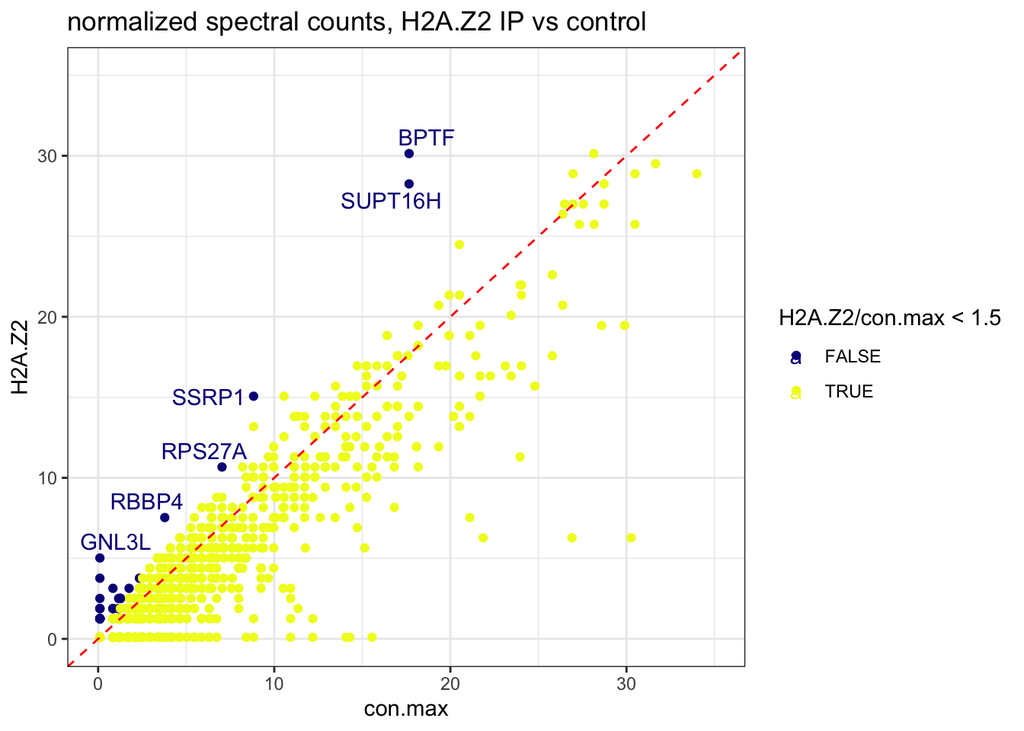

| Acc # | Gene | H2A.Z2 | con.max | ratio_z2_con |
| --- | --- | --- | --- | --- |
| Q05DU1 | GNL3L | 5.023 | 0.1 | 50.229 |
| Q53T70 | RAB10 | 3.767 | 0.1 | 37.672 |
| Q99525 | H4C7 | 2.511 | 0.1 | 25.115 |
| Q29RF7 | PDS5A | 1.884 | 0.1 | 18.836 |
| Q86UV5 | USP48 | 1.884 | 0.1 | 18.836 |
| A0A024R7T5 | ZNF485 | 1.884 | 0.1 | 18.836 |
| Q9H553 | ALG2 | 1.256 | 0.1 | 12.557 |
| P12277 | CKB | 1.256 | 0.1 | 12.557 |
| A0A024R161 | DNAJC25-GNG10 | 1.256 | 0.1 | 12.557 |
| P41091 | EIF2S3 | 1.256 | 0.1 | 12.557 |

[output cut: 36 more lines]

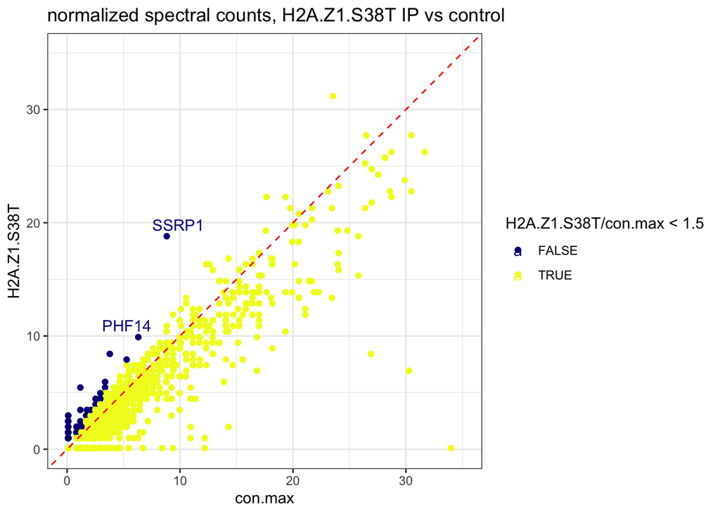

| Acc # | Gene | H2A.Z1.S38T | con.max | ratio_s38t_con |
| --- | --- | --- | --- | --- |
| Q9NYV4 | CDK12 | 2.97 | 0.1 | 29.701 |
| Q96QR8 | PURB | 2.97 | 0.1 | 29.701 |
| Q29RF7 | PDS5A | 2.475 | 0.1 | 24.751 |
| K7EPB9 | TPM4 | 2.475 | 0.1 | 24.751 |
| A2IDB2 | YWHAH | 2.475 | 0.1 | 24.751 |
| Q69YM5 | DKFZp667P103 | 1.98 | 0.1 | 19.801 |
| A0A1D8MAL2 | HLA-A | 1.98 | 0.1 | 19.801 |
| O00468 | AGRN | 1.485 | 0.1 | 14.851 |
| Q9BWT1 | CDCA7 | 1.485 | 0.1 | 14.851 |
| A0A024R161 | DNAJC25-GNG10 | 1.485 | 0.1 | 14.851 |

[output cut: 81 more lines]

Because all three IPs look similar to each other, I decided to treat them as biological replicates and calcualte p-values and plot the data as a volcano plot. Having replicates allows us to statistically control better for variance between runs.

Here we only see two proteins in that quadrant: histone H4 (eg part of the nucleosome bait) and PWWP2A. The latter is a chromatin binding protein that could potentially be interesting:

https://www.nature.com/articles/s41467-018-06665-5

Interestingly it did not standout in any of the individual analysis.

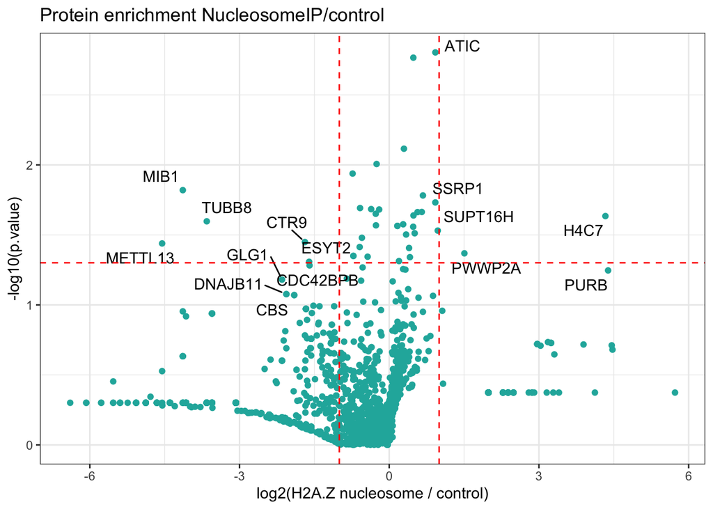

| Acc # | Gene | tar.mean | l2.tarcon | p.value.tarcon |
| --- | --- | --- | --- | --- |
| Q96QR8 | PURB | 2.091 | 4.386 | 0.057 |
| Q99525 | H4C7 | 2.014 | 4.332 | 0.023 |
| Q96N64 | PWWP2A | 2.389 | 1.506 | 0.043 |
| Q9Y5B9 | SUPT16H | 34.647 | 0.973 | 0.029 |
| P31939 | ATIC | 3.338 | 0.925 | 0.002 |
| Q08945 | SSRP1 | 16.750 | 0.924 | 0.019 |

### Conclusions / Future

1. Prep has many non-nuclear proteins in it and I believe needs refinement.
2. Having replicate experiments helps a lot to sort out signal from noise.
3. TMT labeling would provide more robust and reliable quantitation.
4. I’m having issues dealing with homologs in the analysis. Need to work out a better method on my end, which might involve switching search platforms.